## Urban Institute R Graphics Guide

R is a powerful, open-source programming language and environment. R excels at data management and munging, traditional statistical analysis, machine learning, and reproducible research, but it is probably best known for its graphics. This .html file made with [R Markdown](http://rmarkdown.rstudio.com/) contains examples and instructions for popular and lesser-known plotting techniques in R. Furthermore, it includes instructions on how to leverage the Urban Institute’s ggplot2 theme which will create near-publication-ready plots. If you have any questions, please don’t hesitate to contact Aaron Williams (awilliams@urban.org) or Kyle Ueyama (kueyama@urban.org).

#### Using the Urban Institute ggplot2 Theme

Depending on your operating system, run one of the following scripts once per R session:

**Windows**

```
source('https://raw.githubusercontent.com/UrbanInstitute/urban_R_theme/master/urban_theme_windows.R')
```

**Mac**

```
source('https://raw.githubusercontent.com/UrbanInstitute/urban_R_theme/master/urban_theme_mac.R')
```

This is an `R` script that makes `ggplot2` output align more closely with [the Urban Institute’s Data Visualization style guide](http://urbaninstitute.github.io/graphics-styleguide/).

**Run this script once:**

[output not shown]

Loading and importing fonts may take a few minutes.

After the initial installation, to use Lato just load the library in each R session:

```
library(extrafont)
```

#### Grammar of Graphics and Conventions

Hadley Wickham’s ggplot2 is based on Leland Wilkinson’s [*The Grammar of Graphics*](https://www.amazon.com/Grammar-Graphics-Statistics-Computing/dp/0387245448) and Wickham’s [*A Layered Grammar of Graphics*](http://vita.had.co.nz/papers/layered-grammar.html). The layered grammar of graphics is a structured way of thinking about the components of a plot, which then lend themselves to the simple structure of ggplot2.

- **Data** are what are visualizaed in a plot and **mappings** are directions for how data are mapped in a plot in a way that can be perceived by humans.
- **Geoms** are representations of the actual data like points, lines, and bars.
- **Stats** are statistical transformations that represent summaries of the data like histograms.
- **Scales** map values in the data space to values in the aesthetic space. Scales draw legends and axes.
- **Coordinate Systems** describe how geoms are mapped to the plane of the graphic.
- **Facets** break the data into meaningful subsets like small multiples.
- **Themes** control the finer points of a plot such as fonts, font sizes, and background colors.

More information: [ggplot2: Elegant Graphics for Data Analysis](https://www.amazon.com/ggplot2-Elegant-Graphics-Data-Analysis/dp/0387981403)

#### Tips and Tricks

- `ggplot2` expects data to be in data frames. It is preferable for the data frames to be “tidy” with each variable as a column, each obseravtion as a row, and each observational unit as a separate table. `dplyr` and `tidyr` contain concise and effective tools for “tidying” data.
- R allows function arguments to be called explicitly by name and implicitly by position. The coding examples in this guide only contain named arguments for clarity.
- Continuous legends should be switched to vertical using `theme(legend.direction = "vertical")`.
- Graphics will sometimes render differently on different operating systems. This is because anti-aliasing is activated in R on Mac and Linux but not activated in R on Windows. [This blog post](https://www.r-bloggers.com/exporting-nice-plots-in-r/) outlines several fixes for this problem.
- Most features of plots can be adjusted by adding `theme()` to the end of a ggplot call. For example, a plot with a continuous legend would look like this:

```
ggplot(diamonds, aes(carat, price)) +
  stat_binhex(aes(colour = ..count..)) +
  theme(legend.position = "right",
        legend.direction = "vertical")
```

## Bar Plots

### One Color

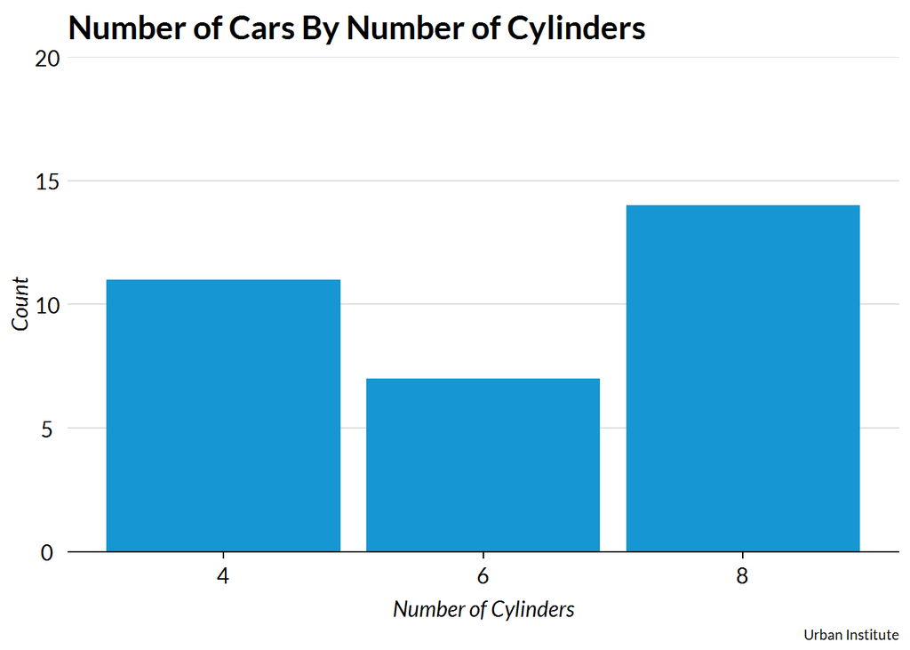

```r
ggplot(data = mtcars, mapping = aes(factor(cyl))) +
  geom_bar() +
  scale_y_continuous(expand = c(0, 0), limits = c(0, 20)) +
  labs(title = "Number of Cars By Number of Cylinders",
       caption = "Urban Institute",
       x = "Number of Cylinders",
       y = "Count")
```

### Three Colors

This is identical to the previous plot except colors and a legend are added with `fill = factor(cyl)`. Turning `x` into a factor with `factor(cyl)` skips 5 and 7 on the `x-axis`. Adding `fill = cyl` without `factor()` would have created a continuous color scheme and legend.

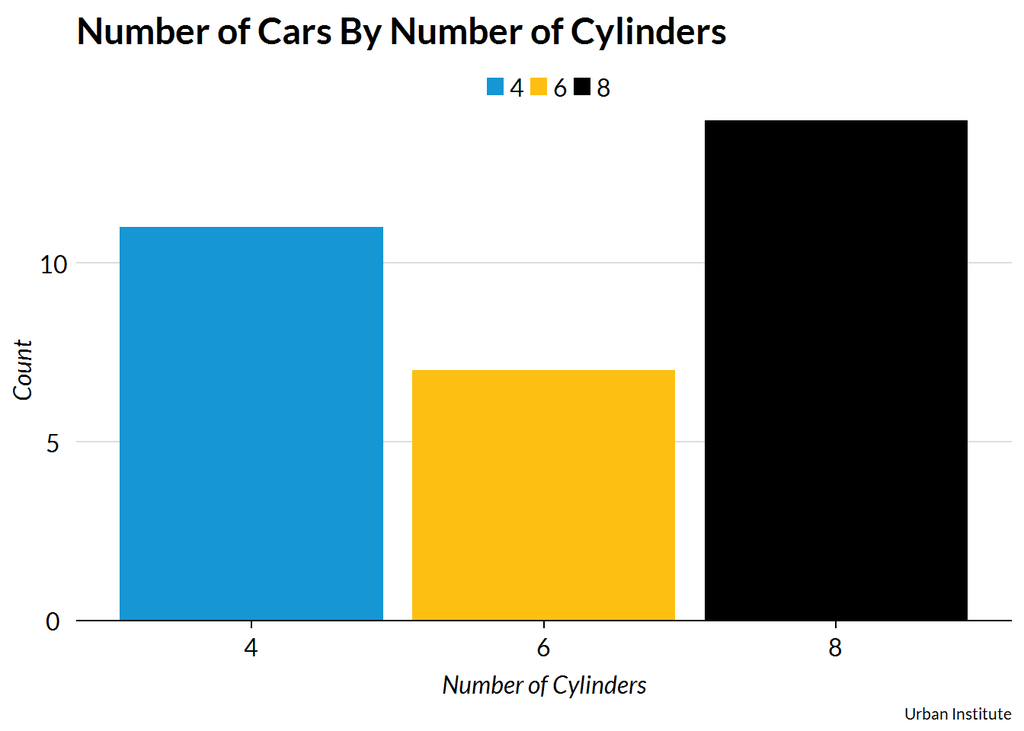

```r
ggplot(data = mtcars, mapping = aes(x = factor(cyl), fill = factor(cyl))) +
  geom_bar() +
  scale_y_continuous(expand = c(0, 0)) +
  labs(title = "Number of Cars By Number of Cylinders",
       caption = "Urban Institute",
       x = "Number of Cylinders",
       y = "Count"
       )
```

### Stacked Bar Plot

An additional aesthetic can easily be added to bar plots by adding `fill = categorical variable` to the mapping. Here, diamond quality subsets each bar showing the count of diamonds with each level of clarity.

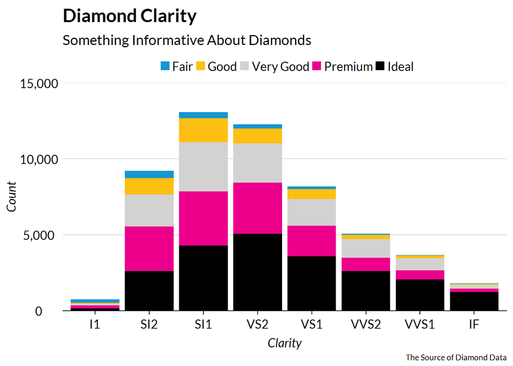

```r
ggplot(data = diamonds, mapping = aes(x = clarity, fill = cut)) +
  geom_bar() +
  scale_y_continuous(expand = c(0, 0), limits = c(0, 15000), labels = scales::comma) +
  labs(
    title = "Diamond Clarity",
    subtitle = "Something Informative About Diamonds",
    caption = "The Source of Diamond Data",
    x = "Clarity",
    y = "Count"
    )
```

### Stacked Bar Plot With Position = Fill

`position = "fill"` in `geom_bar()` changes the y-axis from count to the proportion of each bar.

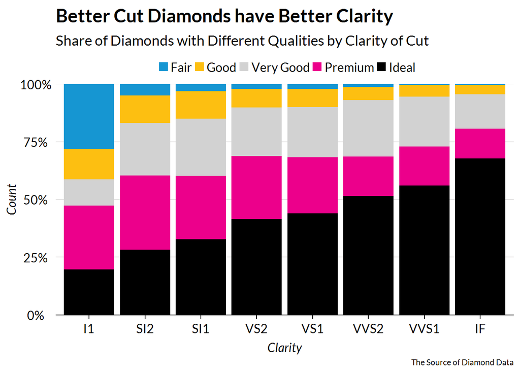

```r
#5 colors (stacked)
ggplot(data = diamonds, mapping = aes(x = clarity, fill = cut)) +
  geom_bar(position = "fill") +
  scale_y_continuous(expand = c(0, 0), labels = scales::percent) +
  labs(title = "Better Cut Diamonds have Better Clarity",
      subtitle = "Share of Diamonds with Different Qualities by Clarity of Cut",
      caption = "The Source of Diamond Data",
      x = "Clarity",
      y = "Count")
```

### Dodged Bar Plot

Subsetted bar charts in ggplot2 are stacked by default. `position = "dodge"` in `geom_bar()` expands the bar chart so the bars appear next to each other.

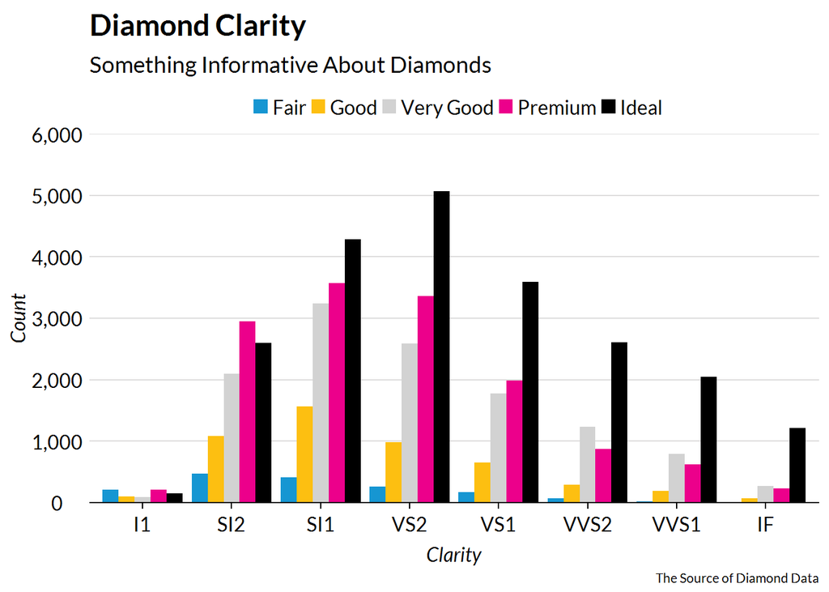

```r
#5 colors (dodged)
ggplot(data = diamonds, mapping = aes(clarity, fill = cut)) +
  geom_bar(position = "dodge") +
  scale_y_continuous(expand = c(0, 0), limits = c(0, 6000), labels = scales::comma) +
  labs(title = "Diamond Clarity",
       subtitle = "Something Informative About Diamonds",
       caption = "The Source of Diamond Data",
       x = "Clarity",
       y = "Count")
```

### Lollipop plot/Cleveland dot plot

Lollipop plots and Cleveland dot plots are minimalist alternatives to bar plots. The key to both plots is to order the data based on the continuous variable using `arrange()` and then turn the discrete variable into a factor with the ordered levels of the continuous variable using `mutate()`. This step “stores” the order of the data.

#### Lollipop plot

[figure not shown]

```r
mtcars %>%
    rownames_to_column("model") %>%
    arrange(mpg) %>%
    mutate(model = factor(model, levels = .$model)) %>%
    ggplot(aes(mpg, model)) +
        geom_segment(aes(x = 0, xend = mpg, y = model, yend = model)) +
        geom_point() +
        scale_x_continuous(expand = c(0, 0), limits = c(0, max(mtcars$mpg) * 1.1)) +
        labs(title = "Miles Per Gallon of Popular Cars",
                 subtitle = "1974 Motor Trend US magazine",
                 x = NULL,
                 y = "Miles Per Gallon",
                 caption = "Urban Institute") +
    theme(axis.text.y = element_text(size = 8))
```

#### Cleveland dot plot

[figure not shown]

```r
mtcars %>%
    rownames_to_column("model") %>%
    arrange(mpg) %>%
    mutate(model = factor(model, levels = .$model)) %>%
    ggplot(aes(mpg, model)) +
        geom_point() +
        scale_x_continuous(expand = c(0, 0), limits = c(0, max(mtcars$mpg) * 1.1)) +
        labs(title = "Miles Per Gallon of Popular Cars",
                 subtitle = "1974 Motor Trend US magazine",
                 x = NULL,
                 y = "Miles Per Gallon",
                 caption = "Urban Institute") +
    theme(axis.text.y = element_text(size = 8))
```

## Scatter Plots

### One Color Scatter Plot

Scatter plots are useful for showing relationships between two or more variables.

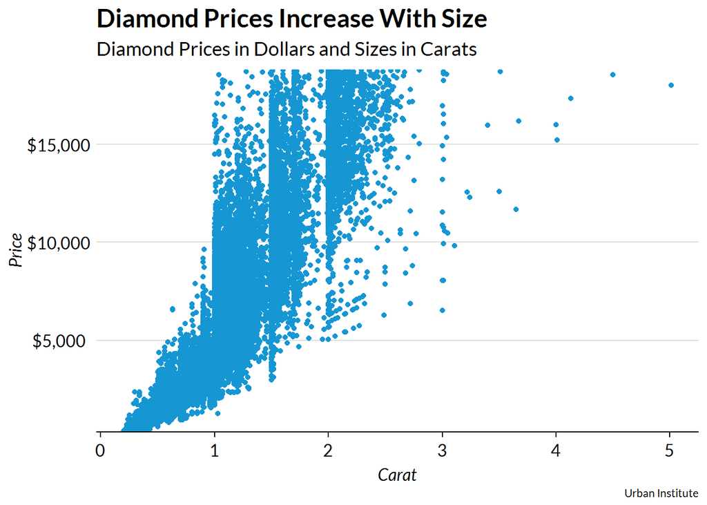

```r
ggplot(data = diamonds, mapping = aes(x = carat, y = price)) +
  geom_point() +
  scale_y_continuous(expand = c(0, 0), labels = scales::dollar) +
  labs(title = "Diamond Prices Increase With Size",
       subtitle = "Diamond Prices in Dollars and Sizes in Carats",
       caption = "Urban Institute",
       x = "Carat",
       y = "Price"
       )
```

### High-Density Scatter Plot with Transparency

Large numbers of observations can sometimes make scatter plots tough to interpret because points overlap. Adding `alpha =` with a number between 0 and 1 adds transparency to points and clarity to plots. Now it’s easy to see that jewelry stores are probably rounding up but not rounding down carats!

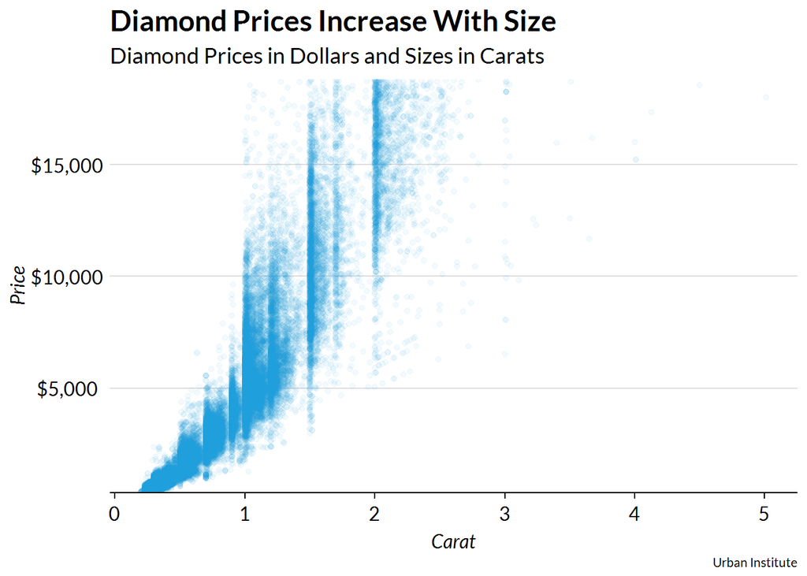

```r
ggplot(data = diamonds, mapping = aes(x = carat, y = price)) +
  geom_point(alpha = 0.05) +
  scale_y_continuous(expand = c(0, 0), labels = scales::dollar) +
  labs(title = "Diamond Prices Increase With Size",
       subtitle = "Diamond Prices in Dollars and Sizes in Carats",
       caption = "Urban Institute",
       x = "Carat",
       y = "Price"
       )
```

### Hex Scatter Plot

Sometimes transparency isn’t enough to bring clarity to a scatter plot with many observations. As n increases into the hundreds of thousands and even millions, `geom_hex` can be one of the best ways to display relationships between two variables.

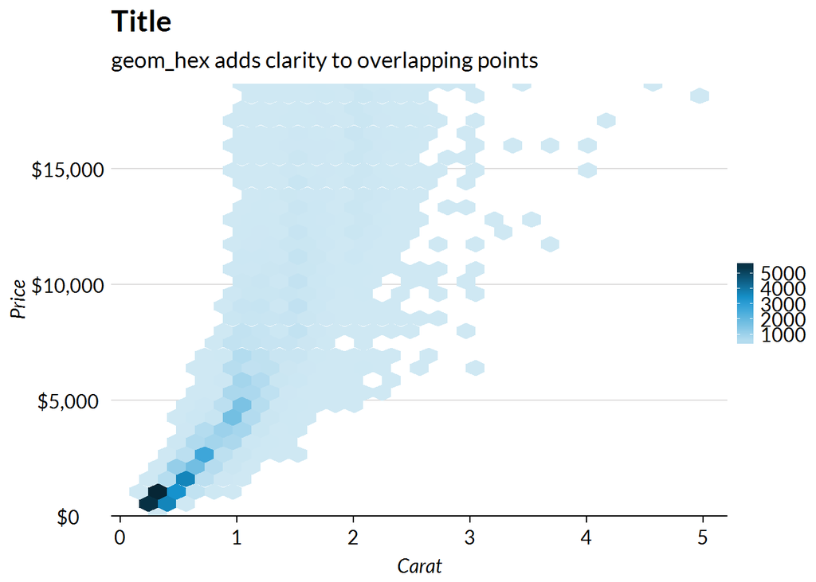

```r
ggplot(data = diamonds, mapping = aes(x = carat, y = price)) +
  geom_hex(mapping = aes(fill = ..count..)) +
  scale_y_continuous(expand = c(0, 0), labels = scales::dollar) +
    scale_fill_gradientn(labels = scales::comma) +
  labs(title = "Title",
       subtitle = "geom_hex adds clarity to overlapping points",
       x = "Carat",
       y = "Price") +
  theme(legend.position = "right",
        legend.direction = "vertical")
```

### Scatter Plots With Random Noise

Sometimes scatter plots have many overlapping points but a reasonable number of observations. `geom_jitter` adds a small amount of random noise so points are less likely to overlap. `width` and `height` control the amount of noise that is added. In the following before-and-after, notice how many more points are visible after adding jitter.

#### Before

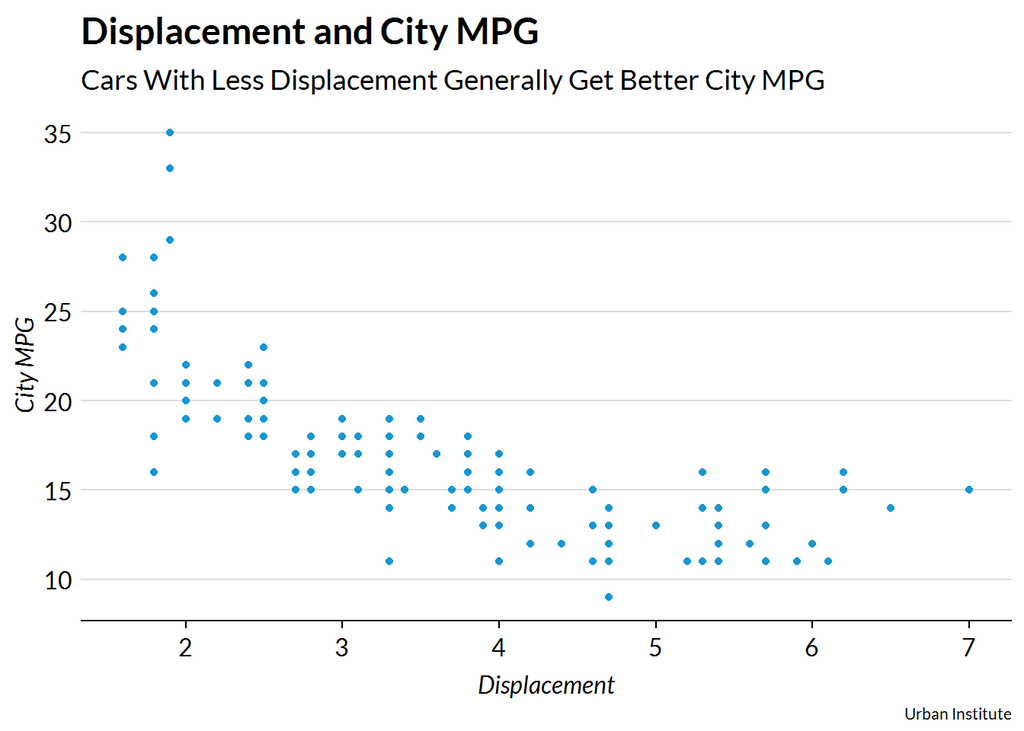

```r
ggplot(data = mpg, mapping = aes(x = displ, y = cty)) +
  geom_point() +
  scale_y_continuous() +
  labs(title = "Displacement and City MPG",
       subtitle = "Cars With Less Displacement Generally Get Better City MPG",
       caption = "Urban Institute",
       x = "Displacement",
       y = "City MPG"
       )
```

#### After

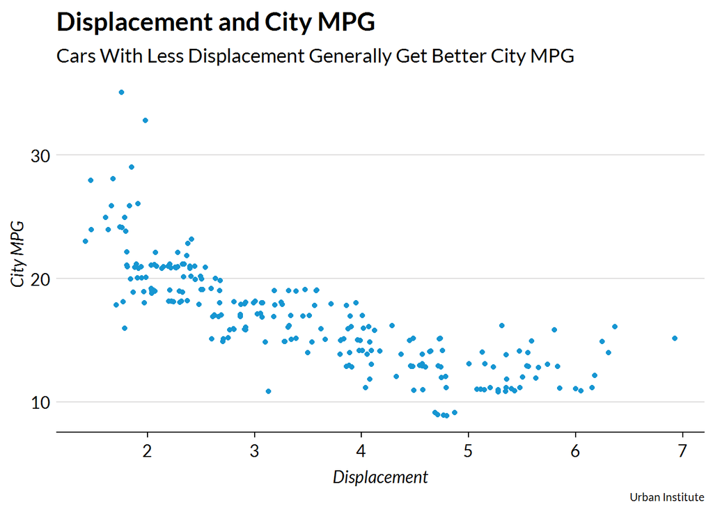

```r
set.seed(2017)
ggplot(data = mpg, mapping = aes(x = displ, y = cty)) +
  geom_jitter(width = 0.2, height = 0.2) +
  scale_y_continuous() +
  labs(title = "Displacement and City MPG",
       subtitle = "Cars With Less Displacement Generally Get Better City MPG",
       caption = "Urban Institute",
       x = "Displacement",
       y = "City MPG"
       )
```

### Scatter Plot with Counts

Another option is to use `geom_count()` to add a size dimension to overlapping points.

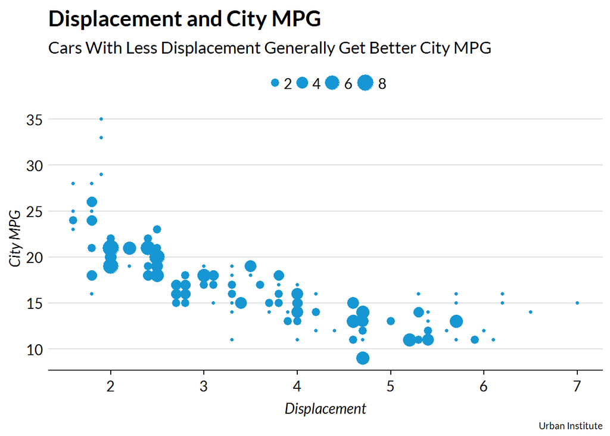

```r
ggplot(data = mpg, mapping = aes(x = displ, y = cty)) +
  geom_count() +
  scale_y_continuous() +
  labs(title = "Displacement and City MPG",
       subtitle = "Cars With Less Displacement Generally Get Better City MPG",
       caption = "Urban Institute",
       x = "Displacement",
       y = "City MPG"
  )
```

### Scatter Plots with Fill

A third aesthetic can be added to scatter plots. Here, color signifies the number of cylinders in each car. Before `ggplot()` is called, Cylinders is created using `library(dplyr)` and the piping operator `%>%`.

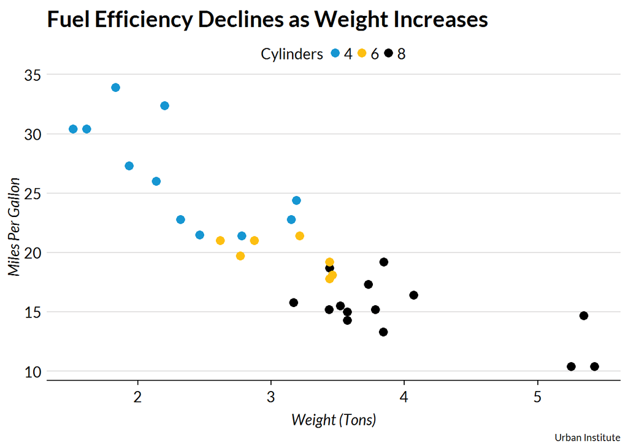

```r
mtcars %>%
  mutate(Cylinders = factor(cyl)) %>%
  ggplot(mapping = aes(x = wt, y = mpg, colour = Cylinders)) +
  geom_point(size = 3) +
  labs(title = "Fuel Efficiency Declines as Weight Increases",
       caption = "Urban Institute",
       x = "Weight (Tons)",
       y = "Miles Per Gallon") +
  theme(legend.title = element_text(hjust = 0))
```

### Bubble Scatter Plot

`size =` can be used as a mapping to plot a fourth dimension.

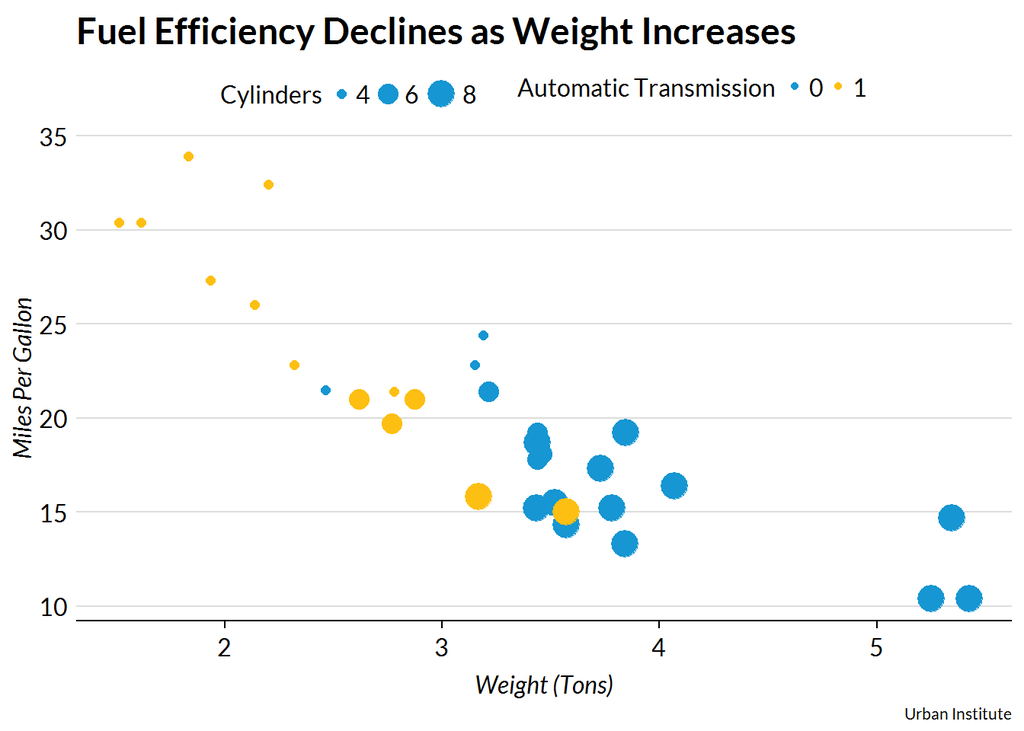

```r
mtcars %>%
  mutate(Cylinders = factor(cyl), `Automatic Transmission` = factor(am)) %>%
  ggplot(mapping = aes(x = wt, y = mpg, color = `Automatic Transmission`, size = Cylinders)) +
  geom_point() +
  labs(title = "Fuel Efficiency Declines as Weight Increases",
       caption = "Urban Institute",
       x = "Weight (Tons)",
       y = "Miles Per Gallon") +
  theme(legend.title = element_text(hjust = 0))
```

## Line Plots

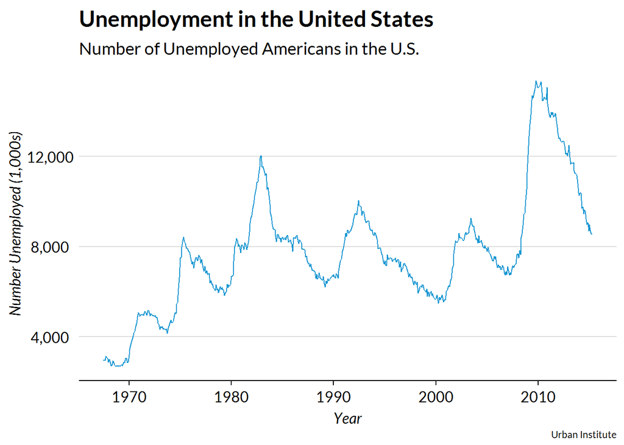

```r
ggplot(data = economics, mapping = aes(x = date, y = unemploy)) +
  geom_line() +
  scale_y_continuous(labels = scales::comma) +
  labs(title = "Unemployment in the United States",
       subtitle = "Number of Unemployed Americans in the U.S.",
       caption = "Urban Institute",
       x = "Year",
       y = "Number Unemployed (1,000s)")
```

### Lines Plots With Multiple Lines

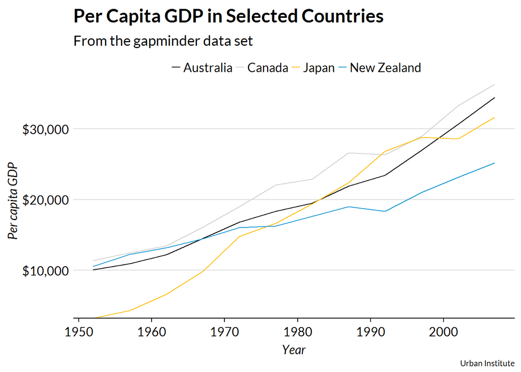

```r
library(tidyverse)
library(gapminder)

gapminder %>%
    filter(country %in% c("Australia", "Canada", "New Zealand", "Japan")) %>%
    ggplot(aes(year, gdpPercap, color = country)) +
    geom_line() +
    scale_y_continuous(expand = c(0, 0),
                                         labels = scales::dollar) +
    labs(title = "Per Capita GDP in Selected Countries",
             subtitle = "From the gapminder data set",
             caption = "Urban Institute",
             x = "Year",
             y = "Per capita GDP")
```

Plotting more than one variable can be useful for seeing the relationship of variables over time, but it takes a small amount of data munging.

[figure not shown]

```r
library(tidyverse)

as_tibble(EuStockMarkets) %>%
    mutate(date = time(EuStockMarkets)) %>%
    gather(key = "key", value = "value", -date) %>%
    ggplot(aes(date, value, color = key)) +
    geom_line() +
  scale_y_continuous(expand = c(0, 0),
                                     labels = scales::dollar,
                                     limits = c(0, 10000)) +
    labs(title = "Major European Stock Indices",
             subtitle = "Based on daily closing prices",
             caption = "Urban Institute",
             x = "Date",
             y = "Value")
```

### Slope plots

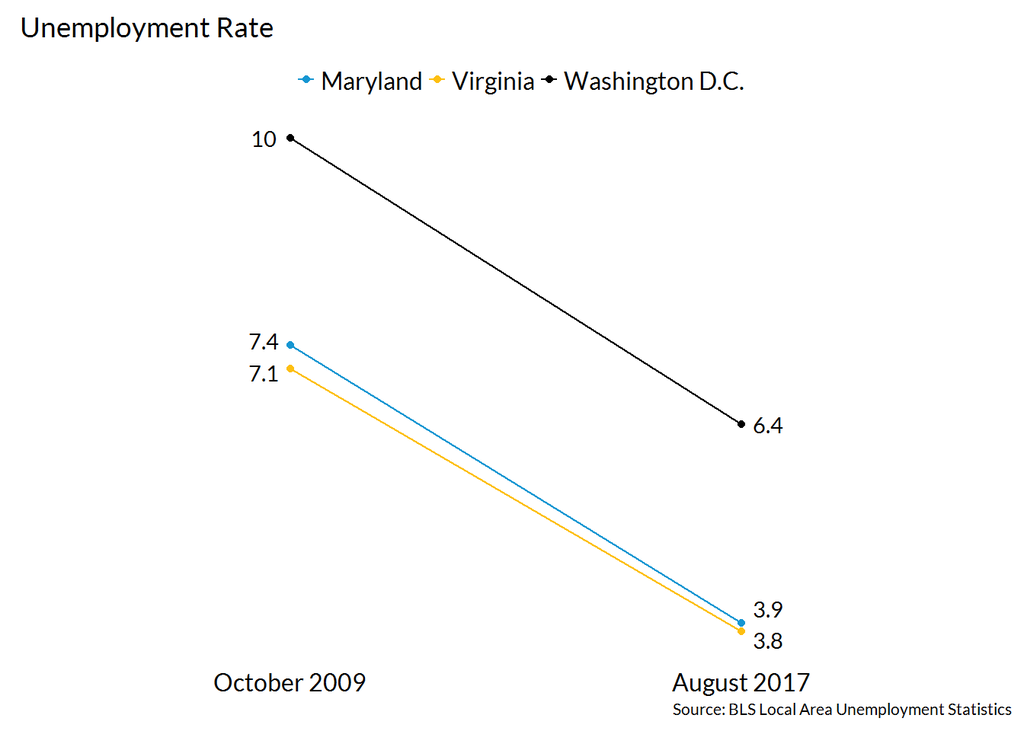

```r
# https://www.bls.gov/lau/

library(ggrepel)

unemployment <- tibble(
    time = c("October 2009", "October 2009", "October 2009", "August 2017", "August 2017", "August 2017"),
    rate = c(7.4, 7.1, 10.0, 3.9, 3.8, 6.4),
    state = c("Maryland", "Virginia", "Washington D.C.", "Maryland", "Virginia", "Washington D.C.")
)

label <- tibble(label = c("October 2009", "August 2017"))
october <- filter(unemployment, time == "October 2009")
august <- filter(unemployment, time == "August 2017")

unemployment %>%
    mutate(time = factor(time, levels = c("October 2009", "August 2017"))) %>%
    ggplot() +
        geom_line(aes(time, rate, group = state, color = state)) +
        geom_point(aes(x = time, y = rate, color = state)) +
        labs(subtitle = "Unemployment Rate",
                 caption = "Source: BLS Local Area Unemployment Statistics") +
        theme(axis.ticks.x = element_blank(),
                    axis.title.x = element_blank(),
                    axis.ticks.y = element_blank(),
          axis.title.y = element_blank(),
          axis.text.y = element_blank(),
                    panel.grid.major.y = element_blank(),
          panel.grid.minor.y = element_blank(),
          panel.grid.major.x = element_blank(),
                    axis.line = element_blank()) +
        geom_text_repel(data = october, mapping = aes(x = time, y = rate, label = as.character(rate)), nudge_x = -0.06) +
        geom_text_repel(data = august, mapping = aes(x = time, y = rate, label = as.character(rate)), nudge_x = 0.06)
```

## Univariate

There are a number of ways to explore the distributions of univariate data in R. Some methods, like strip charts, show all data points. Other methods, like the box and whisker plot, show selected data points that communicate key values like the median and 25th percentile. Finally, some methods don’t show any of the underlying data but calculate density estimates. Each method has advantages and disadvantages, so it is worthwhile to understand the different forms. For more information, read [40 years of boxplots](http://vita.had.co.nz/papers/boxplots.pdf) by Hadley Wickham and Lisa Stryjewski.

### Strip Chart

Strip charts, the simplest univariate plot, show the distribution of values along one axis. Strip charts work best with variables that have plenty of variation. If not, the points tend to cluster on top of each other. Even if the variable has plenty of variation, it is often important to add transparency to the points with `alpha =` so overlapping values are visible.

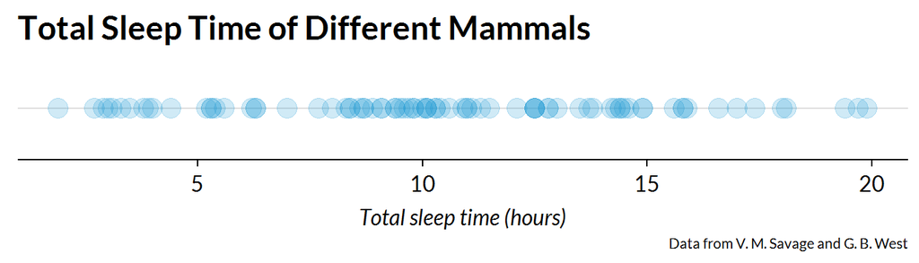

```r
msleep %>%
  ggplot(aes(x = sleep_total, y = factor(1))) +
  geom_point(alpha = 0.2, size = 5) +
  labs(y = NULL) +
  scale_y_discrete(labels = NULL) +
  labs(title = "Total Sleep Time of Different Mammals",
       caption = "Data from V. M. Savage and G. B. West",
       x = "Total sleep time (hours)",
       y = NULL) +
  theme(axis.ticks.y = element_blank())
```

### Strip Chart with Highlighting

Because strip charts show all values, they are useful for showing where selected points lie in the distribution of a variable. The clearest way to do this is by adding `geom_point()` twice with `filter()` in the data argument. This way, the highlighted values show up on top of unhighlighted values.

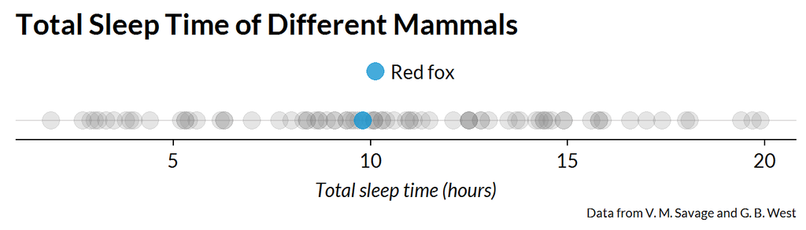

```r
ggplot() +
  geom_point(data = filter(msleep, name != "Red fox"),
                    aes(x = sleep_total,
                        y = factor(1)),
             alpha = 0.2,
             size = 5,
                     color = "grey50") +
  geom_point(data = filter(msleep, name == "Red fox"),
             aes(x = sleep_total,
                 y = factor(1),
                 color = name),
             alpha = 0.8,
             size = 5) +
  labs(y = NULL) +
  scale_y_discrete(labels = NULL) +
  labs(title = "Total Sleep Time of Different Mammals",
       caption = "Data from V. M. Savage and G. B. West",
       x = "Total sleep time (hours)",
       y = NULL,
       legend) +
  guides(color = guide_legend(title = NULL)) +
  theme(axis.ticks.y = element_blank())
```

### Subsetted Strip Chart

Add a y variable to see the distributions of the continuous variable in subsets of a categorical variable.

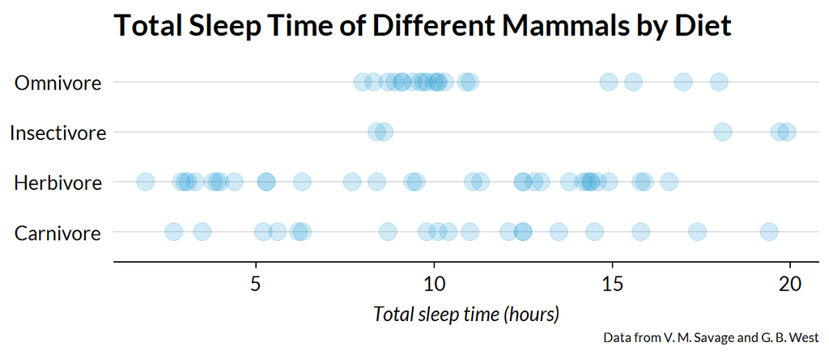

```r
library(forcats)

msleep %>%
  filter(!is.na(vore)) %>%
  mutate(vore = fct_recode(vore,
                            "Insectivore" = "insecti",
                            "Omnivore" = "omni",
                            "Herbivore" = "herbi",
                            "Carnivore" = "carni"
                            )) %>%
  ggplot(aes(x = sleep_total, y = vore)) +
  geom_point(alpha = 0.2, size = 5) +
  labs(title = "Total Sleep Time of Different Mammals by Diet",
       caption = "Data from V. M. Savage and G. B. West",
       x = "Total sleep time (hours)",
       y = NULL) +
  theme(axis.ticks.y = element_blank())
```

### Histograms

Histograms divide the distribution of a variable into n equal-sized bins and then count and display the number of observations in each bin. Histograms are sensitive to bin width. As `?geom_histogram` notes, “You should always override [the default binwidth] value, exploring multiple widths to find the best to illustrate the stories in your data.”

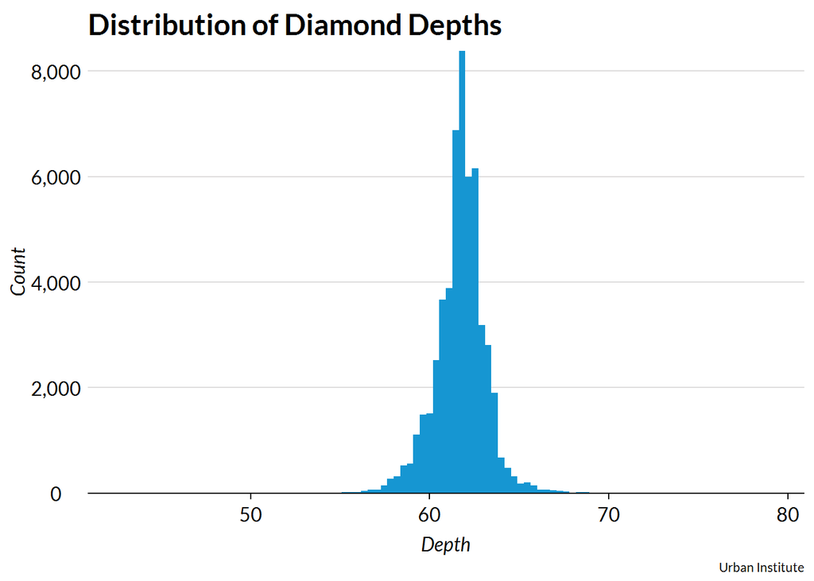

```r
ggplot(data = diamonds, mapping = aes(x = depth)) +
  geom_histogram(bins = 100) +
  scale_y_continuous(expand = c(0, 0), labels = scales::comma) +
  labs(title = "Distribution of Diamond Depths",
       caption = "Urban Institute",
       x = "Depth",
       y = "Count")
```

### Boxplots

Boxplots were invented in the 1970s by John Tukey[^1]. Instead of showing the underlying data or binned counts of the underlying data, they focus on important values like the 25th percentile, median, and 75th percentile.

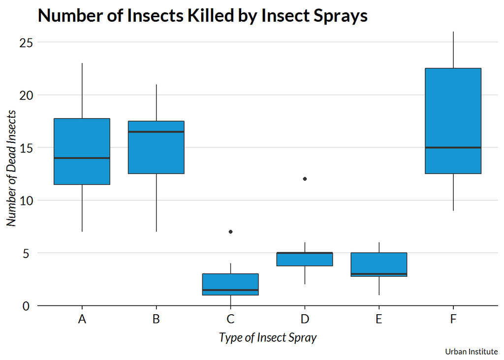

```r
ggplot(InsectSprays, aes(x = spray, y = count)) +
  geom_boxplot() +
  scale_y_continuous(expand = c(0, 0)) +
  labs(title = "Number of Insects Killed by Insect Sprays",
       caption = "Urban Institute",
       x = "Type of Insect Spray",
       y = "Number of Dead Insects")
```

### Smoothed Kernel Density Plots

Continuous variables with smooth distributions are sometimes better represented with smoothed kernel density estimates than histograms or boxplots. `geom_density()` computes and plots a kernel density estimate. Notice the lumps around integers and halves in the following distribution because of rounding.

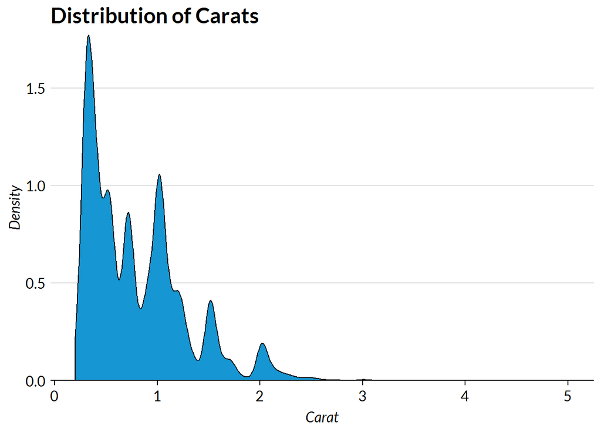

```r
diamonds %>%
  ggplot(aes(carat)) +
  geom_density() +
    scale_y_continuous(expand = c(0, 0)) +
  labs(title = "Distribution of Carats",
       x = "Carat",
       y = "Density")
```

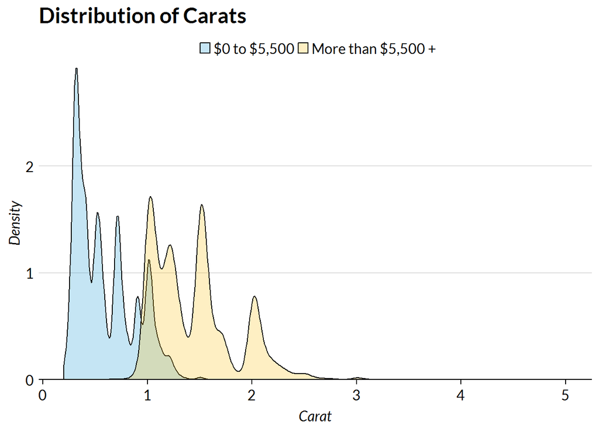

```r
diamonds %>%
  mutate(cost = ifelse(price > 5500, "More than $5,500 +", "$0 to $5,500")) %>%
  ggplot(aes(carat, fill = cost)) +
  geom_density(alpha = 0.25) +
    scale_y_continuous(expand = c(0, 0)) +
  labs(title = "Distribution of Carats",
       x = "Carat",
       y = "Density")
```

### Ridgeline Plots

Ridgeline plots are partially overlapping smoothed kernel density plots faceted by a categorical variable that pack a lot of information into one elegant plot.

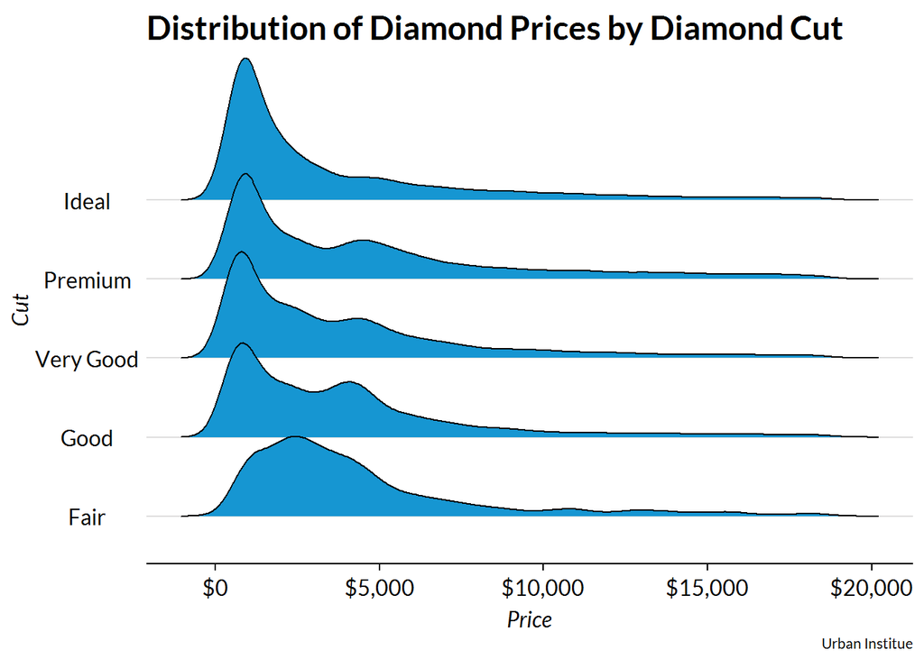

```r
library(ggridges)

ggplot(diamonds, mapping = aes(x = price, y = cut)) +
    geom_density_ridges(fill = "#1696d2") +
    scale_x_continuous(labels = scales::dollar) +
  labs(title = "Distribution of Diamond Prices by Diamond Cut",
       caption = "Urban Institue",
       x = "Price",
       y = "Cut")
```

### Violin Plots

Violin plots are symmetrical displays of smooth kernel density plots.

[figure not shown]

```r
ggplot(InsectSprays, aes(x = spray, y = count, fill = spray)) +
  geom_violin() +
  scale_y_continuous(expand = c(0, 0)) +
  labs(title = "Number of Insects Killed by Insect Sprays",
       caption = "Urban Institute",
       x = "Type of Insect Spray",
       y = "Number of Dead Insects")
```

### Bean Plot

Individual outliers and important summary values are not visible in violin plots or smoothed kernel density plots. Bean plots, [created by Peter Kampstra in 2008](https://www.jstatsoft.org/article/view/v028c01), are violin plots with data shown as small lines in a one-dimensional sstrip plot and larger lines for the mean.

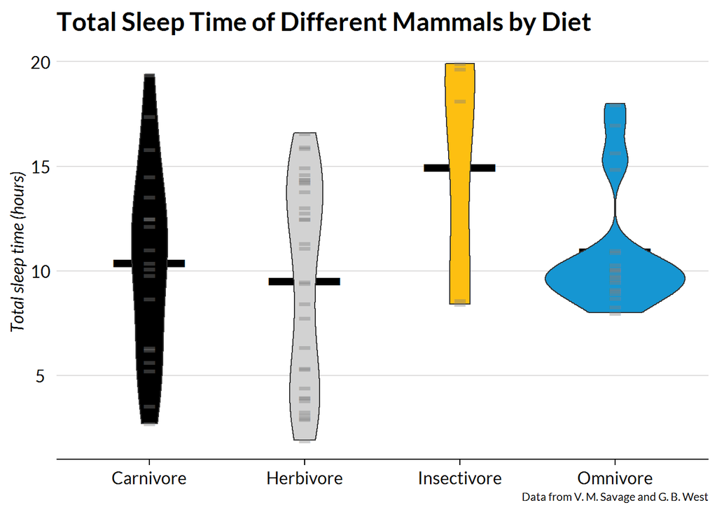

```r
msleep %>%
  filter(!is.na(vore)) %>%
  mutate(vore = fct_recode(vore,
                            "Insectivore" = "insecti",
                            "Omnivore" = "omni",
                            "Herbivore" = "herbi",
                            "Carnivore" = "carni"
                            )) %>%
  ggplot(aes(x = vore, y = sleep_total, fill = vore)) +
  stat_summary(fun.y= "mean",
              colour = "black",
              size = 30,
              shape = 95,
              geom = "point") +
  geom_violin() +
  geom_jitter(width = 0,
              height = 0.05,
              alpha = 0.4,
              shape = "-",
              size = 10,
                        color = "grey50") +
    labs(title = "Total Sleep Time of Different Mammals by Diet",
       caption = "Data from V. M. Savage and G. B. West",
       x = NULL,
       y = "Total sleep time (hours)") +
  theme(legend.position = "none")
```

## Area Plot

### Stacked Area

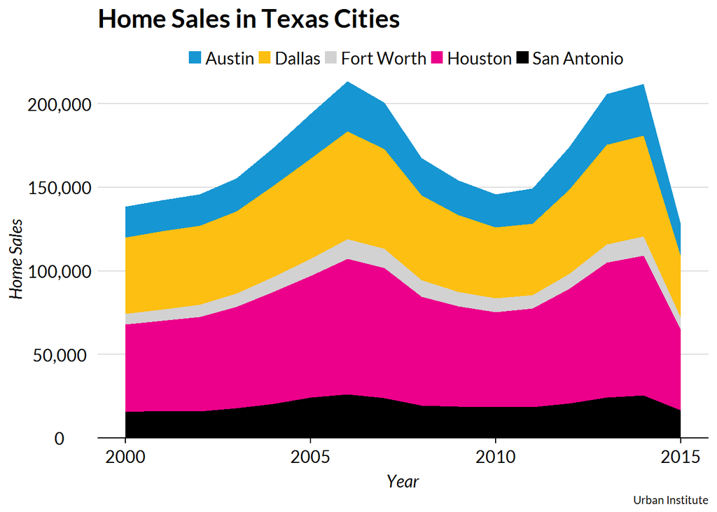

```r
txhousing %>%
  filter(city %in% c("Austin","Houston","Dallas","San Antonio","Fort Worth")) %>%
  group_by(city, year) %>%
  summarize(sales = sum(sales)) %>%
  ggplot(aes(x = year, y = sales, fill = city)) +
    geom_area(position = "stack") +
    scale_y_continuous(expand = c(0, 0), labels = scales::comma) +
    labs(title = "Home Sales in Texas Cities",
         caption = "Urban Institute",
         x = "Year",
         y = "Home Sales")
```

### Filled Area

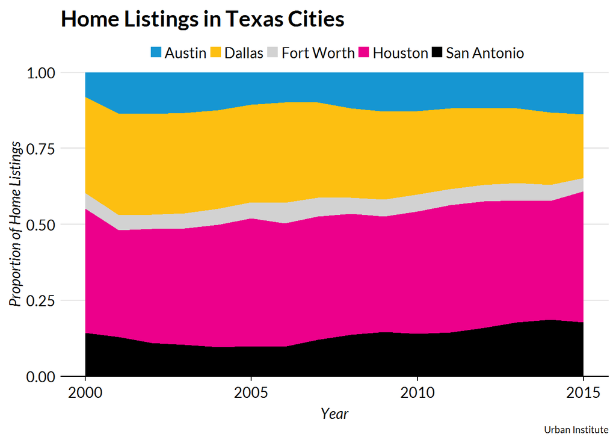

```r
txhousing %>%
  filter(city == "Austin" | city == "Houston"| city == "Dallas"| city == "San Antonio" | city == "Fort Worth") %>%
  group_by(city, year) %>%
  summarize(listings = sum(listings)) %>%
  mutate(listings = ifelse(is.na(listings), lag(listings), listings)) %>%
  ggplot(aes(x = year, y = listings, fill = city)) +
    geom_area(position = "fill") +
    scale_y_continuous(expand = c(0, 0), labels = scales::comma) +
    labs(title = "Home Listings in Texas Cities",
         caption = "Urban Institute",
         x = "Year",
         y = "Proportion of Home Listings")
```